# Business Problem Statement:

### Rank Ordering Stats for Logistic Regression - Oversampled Data

```python
proba_df = pd.DataFrame(proba, columns=['Probablity'])
proba_df['present_decile'] = pd.qcut(proba_df.Probablity, 10, labels=[str(i+1) for i in range(10)])
proba_df.present_decile = proba_df.present_decile.astype(int)

proba_df['response_test'] = y_test_orig
proba_df['response_model'] = proba_df['Probablity'].apply(lambda x: 0 if x<=0.5 else 1)
proba_df['correct_loan_prediction'] = 0
for ind, row in proba_df.iterrows():
    if row['response_test'] == row['response_model'] == 1:
        proba_df.loc[ind, 'correct_loan_prediction'] =1


ks_table = pd.DataFrame({'Decile':[j for j in range(10,0,-1)]})

ks_table['base'] =0
ks_table['responses'] =0
ks_table['non_responses'] =0
for ind, row in ks_table.iterrows():
    ks_table.loc[ind, 'base'] = proba_df[proba_df.present_decile==row['Decile']].shape[0]

    try:
        correct_loan_prediction1 = proba_df[proba_df.present_decile==row['Decile']].correct_loan_prediction.value_counts()[1]
    except:
        correct_loan_prediction1 = 0

    ks_table.loc[ind, 'responses'] = correct_loan_prediction1

ks_table['non_responses'] = ks_table['base'] - ks_table['responses']

ks_table['resp_rate'] = ks_table['responses']/ks_table['base']*100
ks_table['non_resp_rate'] = ks_table['non_responses']/ks_table['base']*100

ks_table['cum_base'] = ks_table.base.cumsum()
ks_table['cum_resp'] = ks_table.responses.cumsum()
ks_table['cum_non_resp'] = ks_table.non_responses.cumsum()

ks_table['cum_resp%'] = ks_table['cum_resp']/ks_table['cum_resp'].max()*100
ks_table['cum_non_resp%'] = ks_table['cum_non_resp']/ks_table['cum_non_resp'].max()*100
ks_table['ks'] = ks_table['cum_resp%']-ks_table['cum_non_resp%']

ks_table['na_label'] = ks_table['cum_resp']/ks_table['cum_base']*100
ks_table['lift'] = ks_table['na_label']/(100*ks_table['cum_resp'].max()/ks_table['cum_base'].max())

ks_table
```

|  | Decile | base | responses | non_responses | resp_rate | non_resp_rate | cum_base | cum_resp | cum_non_resp | cum_resp% | cum_non_resp% | ks | na_label | lift |
| --- | --- | --- | --- | --- | --- | --- | --- | --- | --- | --- | --- | --- | --- | --- |
| 0 | 10 | 495 | 119 | 376 | 24.040404 | 75.959596 | 495 | 119 | 376 | 47.410359 | 8.000000 | 39.410359 | 24.040404 | 4.741994 |
| 1 | 9 | 495 | 78 | 417 | 15.757576 | 84.242424 | 990 | 197 | 793 | 78.486056 | 16.872340 | 61.613715 | 19.898990 | 3.925096 |
| 2 | 8 | 495 | 54 | 441 | 10.909091 | 89.090909 | 1485 | 251 | 1234 | 100.000000 | 26.255319 | 73.744681 | 16.902357 | 3.334007 |
| 3 | 7 | 495 | 0 | 495 | 0.000000 | 100.000000 | 1980 | 251 | 1729 | 100.000000 | 36.787234 | 63.212766 | 12.676768 | 2.500505 |
| 4 | 6 | 495 | 0 | 495 | 0.000000 | 100.000000 | 2475 | 251 | 2224 | 100.000000 | 47.319149 | 52.680851 | 10.141414 | 2.000404 |
| 5 | 5 | 495 | 0 | 495 | 0.000000 | 100.000000 | 2970 | 251 | 2719 | 100.000000 | 57.851064 | 42.148936 | 8.451178 | 1.667003 |
| 6 | 4 | 495 | 0 | 495 | 0.000000 | 100.000000 | 3465 | 251 | 3214 | 100.000000 | 68.382979 | 31.617021 | 7.243867 | 1.428860 |
| 7 | 3 | 495 | 0 | 495 | 0.000000 | 100.000000 | 3960 | 251 | 3709 | 100.000000 | 78.914894 | 21.085106 | 6.338384 | 1.250253 |
| 8 | 2 | 495 | 0 | 495 | 0.000000 | 100.000000 | 4455 | 251 | 4204 | 100.000000 | 89.446809 | 10.553191 | 5.634119 | 1.111336 |
| 9 | 1 | 496 | 0 | 496 | 0.000000 | 100.000000 | 4951 | 251 | 4700 | 100.000000 | 100.000000 | 0.000000 | 5.069683 | 1.000000 |

### Gain Chart

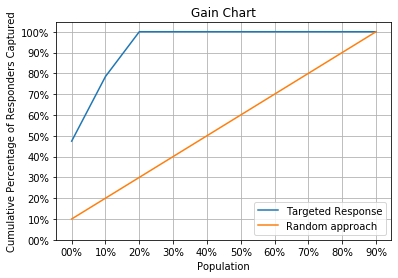

```python
plt.plot([i for i in range(1,11)],ks_table['cum_resp%'], label = 'Targeted Response')
plt.plot([i for i in range(1,11)], np.arange(0, 110, 10)[1:], label = 'Random approach')

plt.xticks(np.arange(1, 11), labels=[(str(i)+'0%') for i in list(range(0,11))])
plt.yticks(np.arange(0, 110, 10), labels=[(str(i)+'0%') for i in list(range(0,11))])

plt.title('Gain Chart')
plt.ylabel('Cumulative Percentage of Responders Captured')
plt.xlabel('Population')
plt.legend()
plt.grid()
plt.show()
```

### Lift Chart

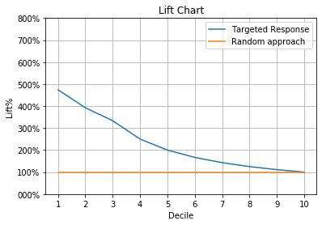

```python
plt.plot([i for i in range(1,11)],ks_table.lift*100, label = 'Targeted Response')
plt.plot([i for i in range(1,11)], [100, 100, 100, 100, 100, 100, 100, 100, 100, 100], label = 'Random approach')

plt.xticks(np.arange(1, 11), labels=[(str(i)) for i in list(range(1,11))])
plt.yticks(np.arange(0, 900, 100), labels=[(str(i)+'00%') for i in list(range(0,11))])

plt.title('Lift Chart')
plt.ylabel('Lift%')
plt.xlabel('Decile')
plt.legend()
plt.grid()

plt.show()
```

### KS chart

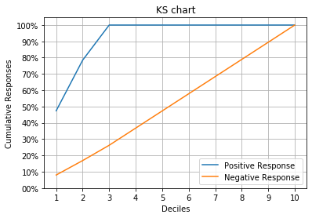

```python
plt.plot([i for i in range(1,11)],ks_table['cum_resp%'], label = 'Positive Response')
plt.plot([i for i in range(1,11)],ks_table['cum_non_resp%'], label = 'Negative Response')
# plt.plot([i for i in range(1,11)], np.arange(0, 110, 10)[1:], label = 'Negative')

plt.xticks(np.arange(1, 11), labels=[(str(i)) for i in list(range(1,11))])
plt.yticks(np.arange(0, 110, 10), labels=[(str(i)+'0%') for i in list(range(0,11))])

plt.title('KS chart')
plt.ylabel('Cumulative Responses')
plt.xlabel('Deciles')
plt.legend()
plt.grid()
plt.show()
```

### ------------------------------------------------------End of Model Exploration---------------------------------------------------------------

### PRE-BUCKETING VISUALIZATIONS FOR INFERENCES

### SCR Vs Occupation Vs Target

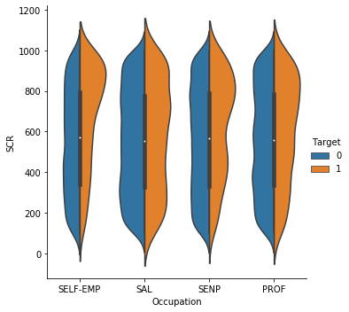

```python
sns.catplot(x="Occupation", y="SCR", hue = "Target",data=data, kind = "violin", split = True)
plt.show()
```

##### Inferences:

- `SELF-EMP` class tends to have more `SCR` values who are likely to opt for loans.
- `SAL` class shows uniformity across `SCR` for people opting/not opting for loans.
- `SENP` business class tend to show similar fashion like `SELF-EMP` class when it comes to opting for loans.
- `PROF` class tends to lie somewhere between `SENP` and `SAL` class.

### SCR Vs Occupation Vs Target

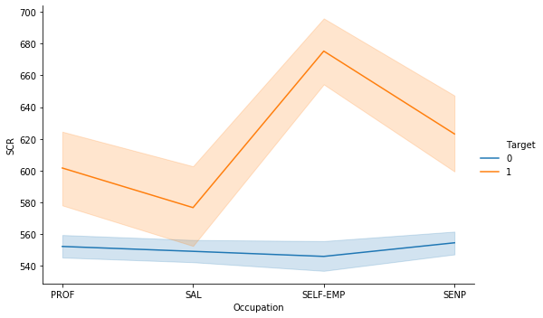

```python
sns.relplot(x="Occupation", y="SCR", hue = "Target",data=data, aspect=1.5, kind = "line")
plt.show()
```

### SCR Vs Occupation Vs Target

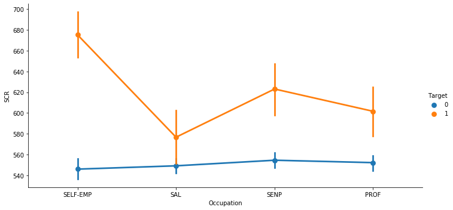

```python
sns.catplot(x="Occupation", y="SCR", hue = "Target",data=data, aspect=2.0, kind = "point")
plt.show()
```

##### Inferences:

- `SELF-EMP`class, there can be seen a high `SCR` value ranging between 660 to 700 points who have shown interest in opting for loans whereas least interest in the same class was shown at 540 to 550 points of `SCR`
- `SENP` class. are the second in line to opt for Loans, as they tend to show comaratively hgiher `SCR` values in the line graph above.

```python
data1 = data.copy()
```

### Bucketing for AGE values

#### pd.qcut() function

```python
data1['Ageb'] = pd.qcut(data['Age'], q=4)
```

```python
data1.head()
```

|  | Target | Age | Gender | Balance | Occupation | No_OF_CR_TXNS | SCR | Holding_Period | Ageb |
| --- | --- | --- | --- | --- | --- | --- | --- | --- | --- |
| 0 | 0 | 41 | M | 91519 | SELF-EMP | 38 | 926 | 15 | (38.0, 46.0] |
| 1 | 0 | 52 | M | 117288 | SAL | 17 | 768 | 13 | (46.0, 55.0] |
| 2 | 0 | 31 | F | 259827 | SENP | 8 | 816 | 5 | (30.0, 38.0] |
| 3 | 0 | 45 | F | 26677 | PROF | 14 | 353 | 18 | (38.0, 46.0] |
| 4 | 0 | 39 | F | 43440 | SENP | 1 | 751 | 31 | (38.0, 46.0] |

#### AGE Intervals

```python
data1.Ageb.value_counts()
```

```
(30.0, 38.0]      5188
(20.999, 30.0]    5136
(46.0, 55.0]      4936
(38.0, 46.0]      4544
Name: Ageb, dtype: int64
```

```python
data1.dtypes
```

```
Target               int64
Age                  int64
Gender              object
Balance              int32
Occupation          object
No_OF_CR_TXNS        int64
SCR                  int64
Holding_Period       int64
Ageb              category
dtype: object
```

```python
data1.Ageb
```

```
0          (38.0, 46.0]
1          (46.0, 55.0]
2          (30.0, 38.0]
3          (38.0, 46.0]
4          (38.0, 46.0]
              ...
19995    (20.999, 30.0]
19996      (30.0, 38.0]
19997      (38.0, 46.0]
19998      (30.0, 38.0]
19999      (30.0, 38.0]
Name: Ageb, Length: 19804, dtype: category
Categories (4, interval[float64]): [(20.999, 30.0] < (30.0, 38.0] < (38.0, 46.0] < (46.0, 55.0]]
```

```python
# sns.pairplot(data1, hue='Target')
```

```python
data1 = pd.get_dummies(data1)
```

```python
data2 = data1.copy()
```